# Asian Dramas Recommendation System

The core of this project centers around a thorough analysis of diverse tags and genres, allowing for accurate recommendations of drama names that align with users' interests, derived from their past viewing history of similar dramas.

```python
import pandas as pd
import numpy as np
import re
import requests
import nltk
import matplotlib.pyplot as plt
from bs4 import BeautifulSoup
from wordcloud import WordCloud, STOPWORDS
from PIL import Image
from ast import literal_eval
from sklearn.feature_extraction.text import CountVectorizer, TfidfTransformer
from nltk.stem.snowball import SnowballStemmer
from sklearn.pipeline import Pipeline
from sklearn.preprocessing import FunctionTransformer
from sklearn.metrics.pairwise import cosine_similarity
```

# Data Scrapping

During the project, I conducted web scraping on MyDramaList's top shows to gather pertinent data like titles, release years, countries, genres, and tags. Subsequently, I compiled all the acquired information into a convenient CSV file for further analysis and processing.

```python
dramalist = []

url = "https://mydramalist.com/shows/top"
response = requests.get(url)
soup = BeautifulSoup(response.text, "html.parser")
lastPage = [a.attrs.get('href') for a in soup.select(".last > a")]
lastNumPage = lastPage[0].split("=")[1]

def GetDrama(url):
    response = requests.get(url)
    soup = BeautifulSoup(response.text, "html.parser")
    dramas = soup.select("h6.title")
    details = soup.select("span.text-muted")
    link = [a.attrs.get('href') for a in soup.select(".film-cover a")]

    for index in range(0, len(dramas)):
        detail = details[index].get_text()
        year = re.search('-(.*?),', detail).group(1)
        data = DramaLookup(year, link[index])
        list.append(data)
```

```python
def DramaLookup(year, link):
    response2 = requests.get("https://mydramalist.com" + link)
    soup2 = BeautifulSoup(response2.text, 'html.parser')

    synopsis = soup2.select(".show-synopsis p")
    synopsis = [s.text for s in synopsis]
    cleanSynopsis = re.sub('\W+', ' ', synopsis[0])

    aka = soup2.select(".mdl-aka-titles a")
    aka2 = [a.text for a in aka]
    aka = (', '.join(aka2))

    genre = soup2.select(".show-genres a")
    genre2 = [g.text for g in genre]
    genre = (', '.join(genre2))

    tags = soup2.select(".show-tags span a")
    tags2 = [t.text for t in tags]
    tags = (', '.join(tags2))

    selectDetails = soup2.select(".box:nth-of-type(2) > .box-body > ul > li")
    sd = [sd.text for sd in selectDetails]
    details = {}
    for i in range(0, len(sd)):
        text = sd[i].split(':', 1)
        details[text[0]] = text[1]

    selectStats = soup2.select(".box:nth-of-type(3) > .box-body > ul > li")
    ss = [ss.text for ss in selectStats]
    for i in range(0, len(ss)):
        text2 = ss[i].split(':', 1)
        details[text2[0]] = text2[1]

    w2wSelect = soup2.select(".wts a b")
    w2w2 = [ww.text for ww in w2wSelect]
    w2w = (', '.join(w2w2))

    cncSelect = [a.attrs.get('title') for a in soup2.select(".credits .p-a-0 > a")]
    cnc = (', '.join(cncSelect))

    try:
        score = re.search('\d.\d', details["Score"]).group(0)
    except AttributeError:
        score = "0"

    cr = details["Content Rating"] if "Content Rating" in details else "Not Yet Rated"
    if cr == " Not Yet Rated":
        cr = "NA"
    else:
        cr = details["Content Rating"].split(" ", 2)[1]

    data = {
        "year": year,
        "title": details["Drama"] if "Drama" in details else "",
        "synopsis": cleanSynopsis,
        "epsCount": details["Episodes"] if "Episodes" in details else "",
        "country": details["Country"] if "Country" in details else "",
        "website": link,
        "watcherCount": details["Watchers"] if "Watchers" in details else "",
        "akaTitle": aka,
        "genre": genre,
        "tags": tags,
        "airedDate": details["Aired"] if "Aired" in details else "",
        "ogNetwork": details["Original Network"] if "Original Network" in details else "",
        "epDuration": details["Duration"] if "Duration" in details else "",
        "score": score,
        "ranked":re.search('\d+', details["Ranked"]).group(0) if "Ranked" in details else "",
        "popularity":re.search('\d+', details["Popularity"]).group(0) if "Popularity" in details else "",
        "contentRating": cr,
        "where2Watch": w2w,
        "top6cast": cnc
    }

    return data
```

```python
for page in range(1, int(lastNumPage)+1):
    urlIn = url + "?page=" + str(page)
    GetDrama(urlIn)
```

```python
df = pd.DataFrame(dramalist)
df.to_csv('dramalist.csv', index=False)
```

# Data Analysis

In order to gain deeper insights into the data and to prepare for the recommendation system, I conducted several data analyses, with a focus on genres, tags, and casts. By exploring and understanding these aspects, we aim to create a robust and effective recommendation system that caters to users' preferences and interests in the world of dramas.

```python
drama_df = pd.read_csv('dramalist.csv')
drama_df.head()
```

|  | year | title | synopsis | epsCount | country | website | watcherCount | akaTitle | genre | tags | airedDate | ogNetwork | epDuration | score | ranked | popularity | contentRating | where2Watch | top6cast |
| --- | --- | --- | --- | --- | --- | --- | --- | --- | --- | --- | --- | --- | --- | --- | --- | --- | --- | --- | --- |
| 0 | 2021 | Move to Heaven | Han Geu Roo is an autistic 20 year old He wor... | 10 | South Korea | /49231-move-to-heaven | 73,018 | Move To Heaven: I Am a Person Who Arranges Art... | Life, Drama | Uncle-Nephew Relationship, Autism, Death, Mour... | May 14, 2021 | Netflix | 52 min. | 9.2 | 9 | 86 | 18+ | Netflix | Lee Je Hoon, Tang Jun Sang, Hong Seung Hee, Ju... |
| 1 | 2015 | Nirvana in Fire | In sixth century China the Emperor of Great L... | 54 | China | /9025-nirvana-in-fire | 25,832 | Rankings of Lang Ya, The Lang Ya Rankings, Lan... | Military, Historical, Drama, Political | Tragic Past, Power Struggle, Smart Male Lead, ... | Sep 19, 2015 - Oct 15, 2015 | BTV | 45 min. | 9.1 | 11 | 439 | 13+ | China Zone, Viki, China Zone - English | Hu Ge, Liu Tao, Wang Kai, Chen Long, Victor Hu... |
| 2 | 2022 | Weak Hero Class 1 | Yeon Shi Eun is a model student who ranks at ... | 8 | South Korea | /702267-weak-hero | 47,440 | Yakhanyeongung Sijeun1, 약한영웅 시즌1, Weak Hero Se... | Action, Youth, Drama | Violence, Friendship, Bromance, School Bullyin... | Nov 18, 2022 | NaN | 40 min. | 9.1 | 15 | 181 | 18+ | Viki, Kocowa, Wavve, iQIYI | Park Ji Hoon, Choi Hyun Wook, Hong Kyung, Kim ... |
| 3 | 2023 | Hidden Love | Sang Zhi falls in love with Duan Jia Xu the b... | 25 | China | /729705-hidden-love | 31,099 | Secretly, Secretly, but Unable to Hide It, Can... | Comedy, Romance, Youth | Secret Crush, Brother-Sister Relationship, Car... | Jun 20, 2023 - Jul 6, 2023 | Youku | 45 min. | 9.1 | 17 | 347 | 13+ | Netflix, YOUKU, YOUKU (优酷) | Zhao Lu Si, Chen Zhe Yuan, Victor Ma, Zeng Li,... |
| 4 | 2021 | Hospital Playlist Season 2 | Everyday is extraordinary for five doctors an... | 12 | South Korea | /57173-hospital-playlist-2 | 50,466 | Hospital Playlist++, 슬기로운 의사 생활 2 | Romance, Life, Drama, Medical | Multiple Mains, Band, Music, Multiple Couples,... | Jun 17, 2021 - Sep 16, 2021 | Netflix, tvN | 1 hr. 40 min. | 9.1 | 18 | 161 | 15+ | TVING, Netflix | Jo Jung Suk, Yoo Yeon Seok, Jung Kyung Ho, Kim... |

```python
genre_words = ''
genre_list = []
stopwords = set(STOPWORDS)

for val in drama_df.genre:
    val = str(val)
    tokens = val.split()
    for i in range(len(tokens)):
        tokens[i] = tokens[i].lower()
        if tokens[i] != "nan":
            genre_list.append(re.sub(r'[^\w\s]', '', tokens[i]))

    genre_words += " ".join(tokens)+ " "
```

```python
mask = np.array(Image.open(r'C:\Users\Ash\Desktop\portfolio\mydramalist\Data Clean\circle.png'))
wordcloud = WordCloud(width= 600, height= 600, mask=mask, background_color='white', stopwords = stopwords).generate(genre_words)
```

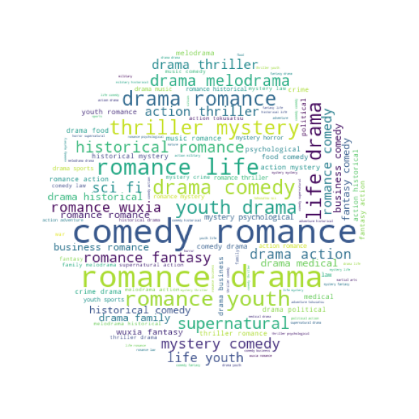

```python
plt.figure(figsize = (8,8), facecolor = None)
plt.imshow(wordcloud)
plt.axis("off")
plt.tight_layout(pad=0)
plt.show()
```

```python
genre_list_unique = list(set(genre_list))
genre_count = [genre_list.count(value) for value in genre_list_unique]
```

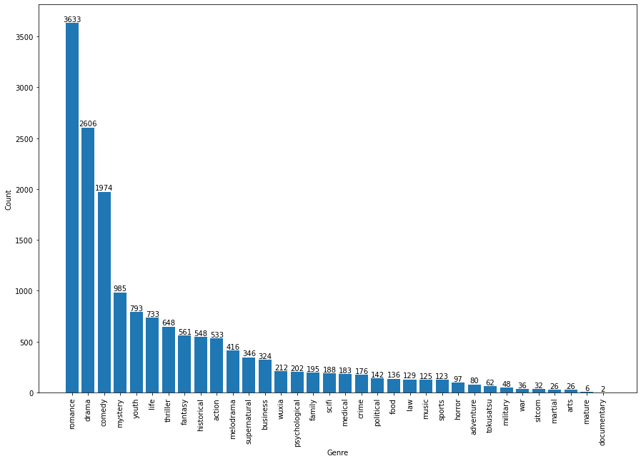

```python
data = {"genre":genre_list_unique,"count":genre_count}
df_genre = pd.DataFrame(data)
df_genres = df_genre.sort_values(by=['count'], ascending=False)
df_count = df_genres['count']
df_genreType = df_genres['genre']
plt.figure(figsize=(15,10))
barC = plt.bar(df_genreType, df_count)
plt.bar_label(barC, df_count, label_type='edge')
plt.xticks(rotation=90)
plt.xlabel("Genre")
plt.ylabel("Count")
plt.show()
```

```python
tags_words = ''
tags_list = []

for val in drama_df.tags:
    val = str(val)
    tokens = val.split()
    for i in range(len(tokens)):
        tokens[i] = tokens[i].lower()
        if tokens[i] != "nan":
            tags_list.append(re.sub(r'[^\w\s]', '', tokens[i]))

    tags_words += " ".join(tokens)+ " "
```

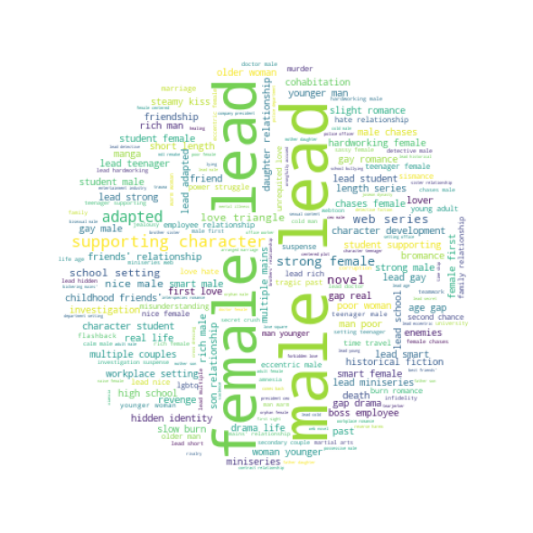

```python
wordcloudTags = WordCloud(width= 600, height= 600, mask=mask, background_color='white', stopwords = stopwords).generate(tags_words)
plt.figure(figsize = (8,8), facecolor = None)
plt.imshow(wordcloudTags)
plt.axis("off")
plt.tight_layout(pad=0)
plt.show()
```

```python
top6cast_words = ''
top6cast_list = []

for val in drama_df.top6cast:
    val = str(val)
    tokens = val.split()
    for i in range(len(tokens)):
        tokens[i] = tokens[i].lower()
        if tokens[i] != "nan":
            top6cast_list.append(re.sub(r'[^\w\s]', '', tokens[i]))

    top6cast_words += " ".join(tokens)+ " "
```

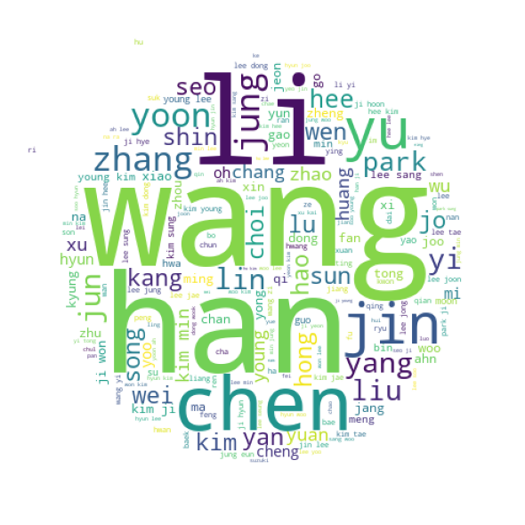

```python
wordcloudtop6cast = WordCloud(width= 600, height= 600, mask=mask, background_color='white', stopwords = stopwords).generate(top6cast_words)
plt.figure(figsize = (8,8), facecolor = None)
plt.imshow(wordcloudtop6cast)
plt.axis("off")
plt.tight_layout(pad=0)
plt.show()
```

```python
country_words = ''
country_list = []

for val in drama_df.country:
    val = str(val)
    country_list.append(val)

print(country_list[0])
```

```
 South Korea
```

```python
country_list_unique = list(set(country_list))
country_count = [country_list.count(value) for value in country_list_unique]
```

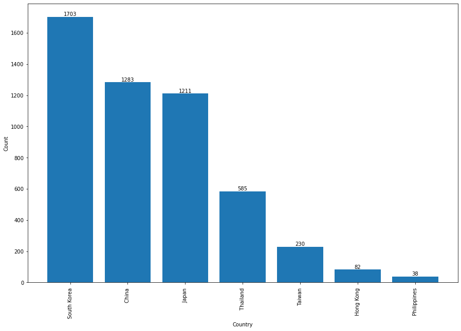

```python
data = {"country":country_list_unique,"count":country_count}
df_country = pd.DataFrame(data)
df_country = df_country.sort_values(by=['count'], ascending=False)
df_count = df_country['count']
df_countryType = df_country['country']
plt.figure(figsize=(15,10))
barC = plt.bar(df_countryType, df_count)
plt.bar_label(barC, df_count, label_type='edge')
plt.xticks(rotation=90)
plt.xlabel("Country")
plt.ylabel("Count")
plt.show()
```

```python
drama_df.head()
```

|  | year | title | synopsis | epsCount | country | website | watcherCount | akaTitle | genre | tags | airedDate | ogNetwork | epDuration | score | ranked | popularity | contentRating | where2Watch | top6cast |
| --- | --- | --- | --- | --- | --- | --- | --- | --- | --- | --- | --- | --- | --- | --- | --- | --- | --- | --- | --- |
| 0 | 2021 | Move to Heaven | Han Geu Roo is an autistic 20 year old He wor... | 10 | South Korea | /49231-move-to-heaven | 73,018 | Move To Heaven: I Am a Person Who Arranges Art... | Life, Drama | Uncle-Nephew Relationship, Autism, Death, Mour... | May 14, 2021 | Netflix | 52 min. | 9.2 | 9 | 86 | 18+ | Netflix | Lee Je Hoon, Tang Jun Sang, Hong Seung Hee, Ju... |
| 1 | 2015 | Nirvana in Fire | In sixth century China the Emperor of Great L... | 54 | China | /9025-nirvana-in-fire | 25,832 | Rankings of Lang Ya, The Lang Ya Rankings, Lan... | Military, Historical, Drama, Political | Tragic Past, Power Struggle, Smart Male Lead, ... | Sep 19, 2015 - Oct 15, 2015 | BTV | 45 min. | 9.1 | 11 | 439 | 13+ | China Zone, Viki, China Zone - English | Hu Ge, Liu Tao, Wang Kai, Chen Long, Victor Hu... |
| 2 | 2022 | Weak Hero Class 1 | Yeon Shi Eun is a model student who ranks at ... | 8 | South Korea | /702267-weak-hero | 47,440 | Yakhanyeongung Sijeun1, 약한영웅 시즌1, Weak Hero Se... | Action, Youth, Drama | Violence, Friendship, Bromance, School Bullyin... | Nov 18, 2022 | NaN | 40 min. | 9.1 | 15 | 181 | 18+ | Viki, Kocowa, Wavve, iQIYI | Park Ji Hoon, Choi Hyun Wook, Hong Kyung, Kim ... |
| 3 | 2023 | Hidden Love | Sang Zhi falls in love with Duan Jia Xu the b... | 25 | China | /729705-hidden-love | 31,099 | Secretly, Secretly, but Unable to Hide It, Can... | Comedy, Romance, Youth | Secret Crush, Brother-Sister Relationship, Car... | Jun 20, 2023 - Jul 6, 2023 | Youku | 45 min. | 9.1 | 17 | 347 | 13+ | Netflix, YOUKU, YOUKU (优酷) | Zhao Lu Si, Chen Zhe Yuan, Victor Ma, Zeng Li,... |
| 4 | 2021 | Hospital Playlist Season 2 | Everyday is extraordinary for five doctors an... | 12 | South Korea | /57173-hospital-playlist-2 | 50,466 | Hospital Playlist++, 슬기로운 의사 생활 2 | Romance, Life, Drama, Medical | Multiple Mains, Band, Music, Multiple Couples,... | Jun 17, 2021 - Sep 16, 2021 | Netflix, tvN | 1 hr. 40 min. | 9.1 | 18 | 161 | 15+ | TVING, Netflix | Jo Jung Suk, Yoo Yeon Seok, Jung Kyung Ho, Kim... |

# Recommendation System

I carefully constructed a dataframe containing essential data, including titles, genres, tags, and the top six casts. In the initial test, I employed the Count Vectorizer to explore the feasibility of developing an accurate recommendation system. The second test involves utilizing the TfidfTransformer to further enhance the recommendation system's performance and accuracy. By employing these techniques, I aim to create a robust and efficient recommendation system that can suggest relevant and personalized drama titles to users based on their interests and preferences.

```python
dramalist_df = drama_df[['title', 'genre', 'tags', 'top6cast']]
dramalist_df.head()
```

|  | title | genre | tags | top6cast |
| --- | --- | --- | --- | --- |
| 0 | Move to Heaven | Life, Drama | Uncle-Nephew Relationship, Autism, Death, Mour... | Lee Je Hoon, Tang Jun Sang, Hong Seung Hee, Ju... |
| 1 | Nirvana in Fire | Military, Historical, Drama, Political | Tragic Past, Power Struggle, Smart Male Lead, ... | Hu Ge, Liu Tao, Wang Kai, Chen Long, Victor Hu... |
| 2 | Weak Hero Class 1 | Action, Youth, Drama | Violence, Friendship, Bromance, School Bullyin... | Park Ji Hoon, Choi Hyun Wook, Hong Kyung, Kim ... |
| 3 | Hidden Love | Comedy, Romance, Youth | Secret Crush, Brother-Sister Relationship, Car... | Zhao Lu Si, Chen Zhe Yuan, Victor Ma, Zeng Li,... |
| 4 | Hospital Playlist Season 2 | Romance, Life, Drama, Medical | Multiple Mains, Band, Music, Multiple Couples,... | Jo Jung Suk, Yoo Yeon Seok, Jung Kyung Ho, Kim... |

```python
#Remove leading space in titles
dramalist_df['title'] = dramalist_df['title'].str.strip()
dramalist_df['title'][0]
```

```
'Move to Heaven'
```

```python
#check for any missing values
dramalist_df.isnull().sum()
```

[output not shown]

```python
#turn the strings into a list
features = ['genre', 'tags', 'top6cast']
for feature in features:
    dramalist_df[feature] = dramalist_df[feature].str.split(", ")
dramalist_df[features].head()
```

|  | genre | tags | top6cast |
| --- | --- | --- | --- |
| 0 | [Life, Drama] | [Uncle-Nephew Relationship, Autism, Death, Mou... | [Lee Je Hoon, Tang Jun Sang, Hong Seung Hee, J... |
| 1 | [Military, Historical, Drama, Political] | [Tragic Past, Power Struggle, Smart Male Lead,... | [Hu Ge, Liu Tao, Wang Kai, Chen Long, Victor H... |
| 2 | [Action, Youth, Drama] | [Violence, Friendship, Bromance, School Bullyi... | [Park Ji Hoon, Choi Hyun Wook, Hong Kyung, Kim... |
| 3 | [Comedy, Romance, Youth] | [Secret Crush, Brother-Sister Relationship, Ca... | [Zhao Lu Si, Chen Zhe Yuan, Victor Ma, Zeng Li... |
| 4 | [Romance, Life, Drama, Medical] | [Multiple Mains, Band, Music, Multiple Couples... | [Jo Jung Suk, Yoo Yeon Seok, Jung Kyung Ho, Ki... |

```python
#Clean data by removing spaces and setting to lowercase
def clean_data(row):
    if isinstance(row, list):
        return [str.lower(i.replace(" ", "")) for i in row]
    else:
        if isinstance(row, str):
            return str.lower(row.replace(" ", ""))
        else:
            return ""

features = ['genre', 'tags', 'top6cast']
for feature in features:
    dramalist_df[feature] = dramalist_df[feature].apply(clean_data)

dramalist_df.head()
```

|  | title | genre | tags | top6cast |
| --- | --- | --- | --- | --- |
| 0 | Move to Heaven | [life, drama] | [uncle-nephewrelationship, autism, death, mour... | [leejehoon, tangjunsang, hongseunghee, jungsuk... |
| 1 | Nirvana in Fire | [military, historical, drama, political] | [tragicpast, powerstruggle, smartmalelead, hid... | [huge, liutao, wangkai, chenlong, victorhuang,... |
| 2 | Weak Hero Class 1 | [action, youth, drama] | [violence, friendship, bromance, schoolbullyin... | [parkjihoon, choihyunwook, hongkyung, kimsugye... |
| 3 | Hidden Love | [comedy, romance, youth] | [secretcrush, brother-sisterrelationship, cari... | [zhaolusi, chenzheyuan, victorma, zengli, qiux... |
| 4 | Hospital Playlist Season 2 | [romance, life, drama, medical] | [multiplemains, band, music, multiplecouples, ... | [jojungsuk, yooyeonseok, jungkyungho, kimdaemy... |

```python
#create a "soup" containing all the metadata extracted for vectorizer use
def create_soup(features):
    return ' '.join(features['genre']) + ' ' + ' '.join(features['tags']) + ' ' + ' '.join(features['top6cast'])

dramalist_df["soup"] = dramalist_df.apply(create_soup, axis=1)
print(dramalist_df["soup"].head())
```

```
0    life drama uncle-nephewrelationship autism dea...
1    military historical drama political tragicpast...
2    action youth drama violence friendship bromanc...
3    comedy romance youth secretcrush brother-siste...
4    romance life drama medical multiplemains band ...
Name: soup, dtype: object
```

The collected data is utilized to calculate the similarity between dramas. The "soup" data, containing relevant information such as genres, tags, and top six casts, undergoes preprocessing and is converted into a vectorizer. By employing the cosine similarity score, we can then measure the similarity between two vectors, ultimately enabling us to recommend relevant and personalized drama titles based on users' preferences and interests. This approach ensures that users receive tailored recommendations, enhancing their overall viewing experience.

```python
count_vectorizer = CountVectorizer(stop_words="english")
count_matrix = count_vectorizer.fit_transform(dramalist_df['soup'])
print(count_matrix.shape)

cosine_sim2 = cosine_similarity(count_matrix, count_matrix)
print(cosine_sim2.shape)

dramalist_df = dramalist_df.reset_index()
indices = pd.Series(dramalist_df.index, index=dramalist_df['title'])
```

```
(5132, 13332)
(5132, 5132)
```

```python
#create a reverse mappping of name and index to make searching easier
indices = pd.Series(dramalist_df.index, index=dramalist_df['title']).drop_duplicates()
print(indices.head(10))
```

```
title
Move to Heaven                0
Nirvana in Fire               1
Weak Hero Class 1             2
Hidden Love                   3
Hospital Playlist Season 2    4
Flower of Evil                5
Hospital Playlist             6
Alchemy of Souls              7
Reply 1988                    8
Reset                         9
dtype: int64
```

```python
def get_recommendations(title, cosine_sim=cosine_sim2):
    idx = indices[title]
    similarity_scores = list(enumerate(cosine_sim[idx]))
    similarity_scores = sorted(similarity_scores, reverse=True)
    similarity_scores = similarity_scores[1:11]
    drama_indices = [ind[0] for ind in similarity_scores]
    dramas = dramalist_df['title'].iloc[drama_indices]
    return dramas
```

```python
print(get_recommendations("Hidden Love", cosine_sim2))
#The result is unexpected and further testing/improvement needs to be made.
```

[output not shown]

In the second test, the TFIDFTransformer is employed to determine similarities between dramas. The "soup" data is processed using the TFIDFTransformer. This technique calculates the importance of each term in the "soup" data by considering its frequency in the document and across all documents. We can enhance the recommendation system's accuracy and provide more refined and tailored drama recommendations to users based on their interests and preferences.

```python
#create a "soup" containing all the metadata extracted for vectorizer use
def create_soup2(features):
    return ' '.join(features['top6cast']) + ' ' + ' '.join(features['tags']) + ' ' + ' '.join(features['genre'])

dramalist_df["soup2"] = dramalist_df.apply(create_soup2, axis=1)
print(dramalist_df["soup2"].head())
```

```
0    leejehoon tangjunsang hongseunghee jungsukyong...
1    huge liutao wangkai chenlong victorhuang dingy...
2    parkjihoon choihyunwook hongkyung kimsugyeom l...
3    zhaolusi chenzheyuan victorma zengli qiuxinzhi...
4    jojungsuk yooyeonseok jungkyungho kimdaemyung ...
Name: soup2, dtype: object
```

```python
#Create a normalized function to normalize the words in description
stemmer = SnowballStemmer("english", ignore_stopwords=False)
def normalized(X):
    normalized = []
    for x in X:
        words = nltk.word_tokenize(x)
        words = [word.lower() for word in words]
        normalized.append(' '.join([stemmer.stem(word) for word in words if re.match('[a-zA-Z]+', word)]))
    return normalized
```

```python
#create a tfidf matrix of the normalized token/word
pipe = Pipeline([
    ('normalize', FunctionTransformer(normalized, validate=False)),
    ('counter_vectorizer', CountVectorizer(
        max_df=0.9, max_features=20000,
        min_df=0.1, stop_words='english',
        ngram_range=(1,3)
    )),
    ('tfidf_transform', TfidfTransformer())
])

tfidf_matrix = pipe.fit_transform([x for x in dramalist_df['soup2']])
```

```python
similarity_distance = cosine_similarity(tfidf_matrix)
```

```python
dramalist_df.index = dramalist_df.index.drop_duplicates(keep="first")
```

```python
#create function to find similar games
def find_similar(title):
    index = dramalist_df[dramalist_df['title'] == title].index[0]
    similarity_score = list(enumerate(similarity_distance[index]))
    similarity_score = sorted(similarity_score, key=lambda x:x[1], reverse=True)
    similarity_score = similarity_score[2:17]
    drama_index = [ind[0] for ind in similarity_score]
    most_similar = dramalist_df.iloc[drama_index, 1]
    return most_similar
```

```python
print("Top 15 Recommendations")
print(find_similar('Move to Heaven'))
```

```
Top 15 Recommendations
132                                      Move to Heaven
162                                           Navillera
403                                            The Bond
420                                 Recipe for Farewell
459                                My Unfamiliar Family
558                      Bokura wa Kiseki de Dekite Iru
703                                       Salon De Nabi
868                                        Minning Town
1227                                        My Treasure
1325                          Rental Nan mo Shinai Hito
1391    Unsung Cinderella: Byoin Yakuzaishi no Shohosen
1979                              Late Night Restaurant
2031                                                Awl
2142                                    Heaven's Garden
2307                    Mokomi: Kanojo Chotto Hendakedo
Name: title, dtype: object
```

```python
print("Top 15 Recommendations")
print(find_similar('Hospital Playlist'))
```

```
Top 15 Recommendations
699         Nothing But Thirty
2154             Love Yourself
309               Age of Youth
2198                  Dear Mom
3583               Love Family
3115            My True Friend
54      Twenty-Five Twenty-One
91                   Our Blues
186     Twenty-Five Twenty-One
223                  Our Blues
844                Okaeri Mone
1018              Back to 1989
1721        Healer of Children
2256           The Way We Were
2554      Triumph in the Skies
Name: title, dtype: object
```

```python
print("Top 15 Recommendations")
print(find_similar('Goblin'))
```

```
Top 15 Recommendations
546        My Girlfriend Is an Alien Season 2
623                        Are You Human Too?
707                          A Korean Odyssey
795                 Miss Crow with Mr. Lizard
843     Once Upon a Time in Lingjian Mountain
861                              Love in Time
1105                         Kiss Sixth Sense
1197                      Miracle That We Met
1371                 Chinese Paladin Season 3
1573                         Where Stars Land
1777                         My Lonely Planet
2866                       Love Forever After
2977                       Seishun Cinderella
3027                 Chinese Paladin Season 5
3060           Buried City to Shut All Lights
Name: title, dtype: object
```